# Laboratory16

# Introduction

This lab is about **correlation**, **adjusted R squared** and **prediction**.

We will be looking at the `Pearson moment correlation coefficient` defined as

$$r = \frac{SS_{xy}}{\sqrt{SS_{xx}SS_{yy}}}$$
this measures the amount of linear relationship between two variables x, and y.

This is related to another very important statistic, the `coefficient of determination` otherwise known as `multiple r squared`. This is defined as

$$R^2 = \frac{MSS}{TSS}$$
This is quantifying the fraction of the **TSS** (Total sum of squares = variability of the response = $SS_{yy}$) explained by the model. We sometimes express this as a percentage, example, if $R^2=0.6456$ then we might say:

> 64.56% of the variabilty in the response is explained by the model through x

For SLR we can derive

$$R^2 = r^2$$

When we wish to predict a new response $y$ given a particular x value $x_p$ or if we wish to predict a mean response $E(Y)$ given an x value $x_p$ we call this **prediction**. There are many functions in R that will help you do this. The main one is `predict()`.

# The data

The data has been packaged in the current library.

```r
data("liquid")
head(liquid)
```

| TIME | MASS |
| --- | --- |
| 0 | 6.64 |
| 1 | 6.34 |
| 2 | 6.04 |
| 4 | 5.47 |
| 6 | 4.94 |
| 8 | 4.44 |

## Plot the data

In order to examine the trend in the data we will use a loess smoother:

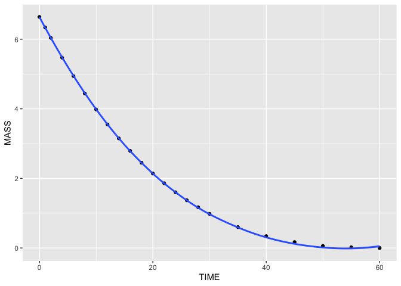

```r
library(ggplot2)
g <- ggplot(liquid, aes(x = TIME, y = MASS)) + geom_point()
g1 <- g + geom_smooth(method = "loess", formula = y~x)
g1
```

The plot has a curved trend. It is likely we should not conclude with a straight line but we could start with this and then make improvements.

## Straight line, quadratic or exponential?

A SLR line would be easy to fit under either paradigm. Lets make a raft of models and name the objects `ylm1, ylm2, ...` and use adjusted $R^2$ to choose between them.

```r
ylm1 <- lm(MASS ~ TIME, data = liquid)
ylm2 <- lm(MASS ~ TIME + I(TIME^2), data = liquid)
ylm3 <- lm(log(MASS+1) ~ TIME + I(TIME^2), data=liquid)
s1 <- summary(ylm1)
s2 <- summary(ylm2)
s3 <- summary(ylm3)
Rasq <- list(Rasq1 = s1$adj.r.squared,
               Rasq2 = s2$adj.r.squared,
               Rasq3 = s3$adj.r.squared)
Rasq
ws#> $Rasq1
ws#> [1] 0.846355
ws#>
ws#> $Rasq2
ws#> [1] 0.9967687
ws#>
ws#> $Rasq3
ws#> [1] 0.9945679
```

The second model is the winner (Largest $R_a^2$) but not by much.

We will use a quadratic to model the relationship.

```r
sm <- summary(ylm2)
cf = coef(ylm2)
cf
ws#>  (Intercept)         TIME    I(TIME^2)
ws#>  6.472256080 -0.266725281  0.002721568
```

The model is now

$$\widehat{MASS} = 6.4722561 + -0.2667253*TIME + 0.0027216*TIME^2$$

We can now plot the fitted model

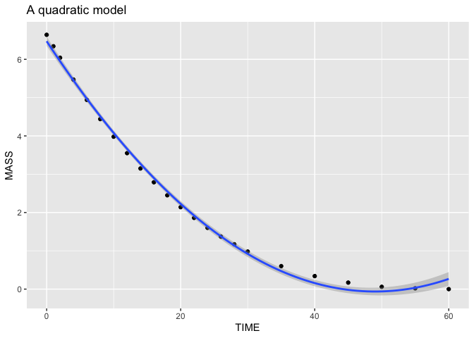

```r
g2 <- g + geom_smooth(method = "lm", formula = y~x+I(x^2))
g2 <- g2 + ggtitle("A quadratic model")
g2
```

### Criticism

The model works well within most of the domain of `TIME` but at the extreme end the estimating trend turns up – this is a property of the quadratic (coefficient of $TIME^2$ is positive) and would not be of much concern for estimation and prediction within most of the range of TIME. It does give interpretational problems however, at extreme TIME values – it gives the appearance that MASS would begin to increase with higher TIME.

## Using the exponential model

The model I would like us to look at is the non linear exponential model (you can see that the model is non linear in $\beta_1$ and $\beta_2$)

$$E(MASS|TIME) = \beta_0 e^{\beta_1 TIME + \beta_2 TIME^2}$$
We will use the `nls` function in the `STATS` base package.

```r
summary(liquid)
ws#>       TIME            MASS
ws#>  Min.   : 0.00   Min.   :0.000
ws#>  1st Qu.: 9.00   1st Qu.:0.790
ws#>  Median :20.00   Median :2.140
ws#>  Mean   :22.87   Mean   :2.613
ws#>  3rd Qu.:32.50   3rd Qu.:4.210
ws#>  Max.   :60.00   Max.   :6.640
nls1 <- nls(formula = MASS ~ b0*exp(b1*TIME + b2*TIME^2 ),
            data = liquid,
            start = list(b0 = 7, b1 = -0.05,b2  = - 0.0005 ),
            trace = TRUE
            )
ws#> 0.4379162 :   7e+00 -5e-02 -5e-04
ws#> 0.02734847 :   6.6015697629 -0.0431912606 -0.0006951897
ws#> 0.02698689 :   6.6039744808 -0.0431058768 -0.0006942914
ws#> 0.02698681 :   6.6038809865 -0.0430996794 -0.0006945901
ws#> 0.02698681 :   6.6038864576 -0.0431001151 -0.0006945675
ws#> 0.02698681 :   6.6038860196 -0.0431000807 -0.0006945693
summary(nls1)
ws#>
ws#> Formula: MASS ~ b0 * exp(b1 * TIME + b2 * TIME^2)
ws#>
ws#> Parameters:
ws#>      Estimate Std. Error t value Pr(>|t|)
ws#> b0  6.604e+00  2.384e-02  277.00  < 2e-16 ***
ws#> b1 -4.310e-02  8.661e-04  -49.76  < 2e-16 ***
ws#> b2 -6.946e-04  3.633e-05  -19.12 2.55e-14 ***
ws#> ---
ws#> Signif. codes:  0 '***' 0.001 '**' 0.01 '*' 0.05 '.' 0.1 ' ' 1
ws#>
ws#> Residual standard error: 0.03673 on 20 degrees of freedom
ws#>
ws#> Number of iterations to convergence: 5
ws#> Achieved convergence tolerance: 9.074e-07
```

## Plot the exponential model

We will now plot the points and use the estimates created above using Base R.

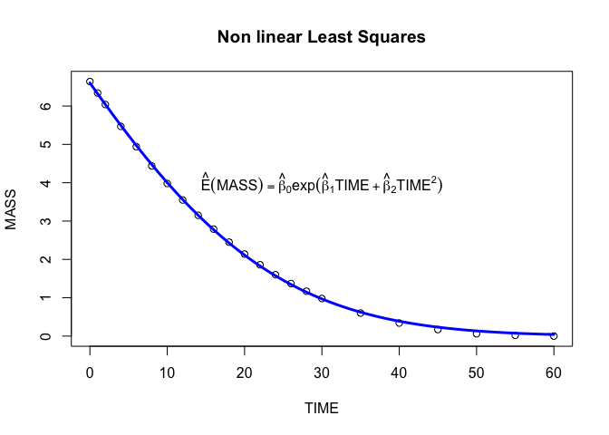

```r
cf <- coef(nls1)

mynlsfun <- function(x) cf[1]*exp(cf[2]*x + cf[3]*x^2)

plot(MASS ~ TIME, data = liquid, main = "Non linear Least Squares")


curve(mynlsfun, lwd = 3, col = "Blue", add = TRUE)
text(30,4, expression(hat(E)(MASS)==hat(beta)[0]*exp(hat(beta)[1]*TIME + hat(beta)[2]*TIME^2)))
```

# Finally

With this brief introduction you may now start on the lab

Lab16.R, MATH4753Laboratory16.docx